# Lab 1: Subsetting and exploring data

## Data for today

In addition to data that you can import from a spreadsheet, there are many example datasets that come installed with R and its packages. To see a list of these datasets:

```r
data()
```

Today we’ll explore the `CO2` dataset. We’ll also use the `data` function to load it into our environment.

```r
data(CO2)
```

Since this is an example dataset, it also has a help page.

```r
?CO2
```

```
## starting httpd help server ... done
```

Take a moment to view the dataset (by printing the whole thing to the console, or clicking it in the Environment pane). You can also use the `str` function to learn more about it. There is some information printed out by `str` that you might not understand yet, but other information that is useful. What are the column names, and what type of data does each contain? How many observations are there?

Make a new project in RStudio. Create a script file in the main folder that will contain all of your work for today. Create a folder called “data”. Save a copy of the `CO2` data frame to a CSV in that folder (so we can pretend that we’re working with our own data), and add a line to your script to read the data in from CSV. As you work, be sure to add some comments to your script to remind yourself of what is happening.

## Installing and loading a package

We’ll try out two methods for exploring and subsetting our data today. The R “base” has a system that is very flexible. On the other hand, the Tidyverse package `dplyr` has a syntax that is a bit more human readable and easier for beginners. Try them both out and use whichever you prefer (or some combination of the two).

To install `dplyr` (or any other R package), you only need to run `install.packages` once. You might type this command directly into the console, or put it into your script but comment it out so that you don’t accidentally run it again.

```r
install.packages("dplyr")
```

To load a package into your environment, use the `library` function. Generally it is good practice to make all calls to `library` at the very top of your script, so that if you are using the script on another computer, or sharing it with someone else, it is easy to see what packages are required.

```r
library(dplyr)
```

The package name has to be in quotes for `install.packages`, but not for `library`. There isn’t a very good reason for this; it is one of R’s quirks.

To pull up a tutorial on `dplyr`, run

```r
vignette("dplyr")
```

Many packages have “vignette” tutorials in addition to the documentation pages for individual functions. Later in the class when you learn to make your own packages, you will also learn to make vignettes.

## Filtering rows of a data frame

Say we only want to look at the plants from Mississippi. If we run

```r
CO2$Type == "Mississippi"
```

```
##  [1] FALSE FALSE FALSE FALSE FALSE FALSE FALSE FALSE FALSE FALSE FALSE
## [12] FALSE FALSE FALSE FALSE FALSE FALSE FALSE FALSE FALSE FALSE FALSE
## [23] FALSE FALSE FALSE FALSE FALSE FALSE FALSE FALSE FALSE FALSE FALSE
## [34] FALSE FALSE FALSE FALSE FALSE FALSE FALSE FALSE FALSE  TRUE  TRUE
## [45]  TRUE  TRUE  TRUE  TRUE  TRUE  TRUE  TRUE  TRUE  TRUE  TRUE  TRUE
## [56]  TRUE  TRUE  TRUE  TRUE  TRUE  TRUE  TRUE  TRUE  TRUE  TRUE  TRUE
## [67]  TRUE  TRUE  TRUE  TRUE  TRUE  TRUE  TRUE  TRUE  TRUE  TRUE  TRUE
## [78]  TRUE  TRUE  TRUE  TRUE  TRUE  TRUE  TRUE
```

we get a Boolean vector, with `TRUE` for rows from Mississippi and `FALSE` for rows from Quebec. We can use that vector to get a smaller data frame with just those rows.

```r
CO2_Miss <- CO2[CO2$Type == "Mississippi", ]
```

Alternatively, we can use the `filter` function in `dplyr`.

```r
CO2_Miss <- filter(CO2, Type == "Mississippi")
```

Are the results of these two methods different at all? How?

You can filter based on multiple criteria, say only chilled plants from Mississippi. In R base:

```r
CO2_Miss_chilled <- CO2[CO2$Type == "Mississippi" & CO2$Treatment == "chilled", ]
```

In `dplyr`:

```r
CO2_Miss_chilled <- filter(CO2, Type == "Mississippi", Treatment == "chilled")
```

**Question 1 to turn in:** Using your choice of R base or `dplyr`, write a line to filter the `CO2` data frame, returning rows from the chilled treatment where CO2 concentration (`conc`) is above 400.

```
##    Plant        Type Treatment conc uptake
## 1    Qc1      Quebec   chilled  500   32.5
## 2    Qc1      Quebec   chilled  675   35.4
## 3    Qc1      Quebec   chilled 1000   38.7
## 4    Qc2      Quebec   chilled  500   38.6
## 5    Qc2      Quebec   chilled  675   37.5
## 6    Qc2      Quebec   chilled 1000   42.4
## 7    Qc3      Quebec   chilled  500   38.9
## 8    Qc3      Quebec   chilled  675   39.6
## 9    Qc3      Quebec   chilled 1000   41.4
## 10   Mc1 Mississippi   chilled  500   19.5
## 11   Mc1 Mississippi   chilled  675   22.2
## 12   Mc1 Mississippi   chilled 1000   21.9
## 13   Mc2 Mississippi   chilled  500   12.5
## 14   Mc2 Mississippi   chilled  675   13.7
## 15   Mc2 Mississippi   chilled 1000   14.4
## 16   Mc3 Mississippi   chilled  500   17.9
## 17   Mc3 Mississippi   chilled  675   18.9
## 18   Mc3 Mississippi   chilled 1000   19.9
```

## Sorting a data frame

R has a `sort` function, if you want to sort a single vector:

```r
sort(CO2$uptake)
```

```
##  [1]  7.7  9.3 10.5 10.6 10.6 11.3 11.4 12.0 12.3 12.5 13.0 13.6 13.7 14.2
## [15] 14.4 14.9 15.1 16.0 16.2 17.9 17.9 17.9 18.0 18.1 18.9 18.9 19.2 19.4
## [29] 19.5 19.9 21.0 21.9 22.0 22.2 24.1 25.8 26.2 27.3 27.3 27.8 27.9 28.1
## [43] 28.5 30.0 30.3 30.4 30.6 30.9 31.1 31.5 31.8 32.4 32.4 32.4 32.5 34.0
## [57] 34.6 34.8 35.0 35.3 35.4 35.5 37.1 37.2 37.5 38.1 38.6 38.7 38.8 38.9
## [71] 39.2 39.6 39.7 40.3 40.6 41.4 41.4 41.8 42.1 42.4 42.9 43.9 44.3 45.5
```

There is also the `order` function, if you want to sort a vector, data frame, or mulitiple vectors based on one or more vectors.

```r
CO2$uptake[order(CO2$conc)]
```

```
##  [1] 16.0 13.6 16.2 14.2  9.3 15.1 10.6 12.0 11.3 10.5  7.7 10.6 30.4 27.3
## [15] 32.4 24.1 27.3 21.0 19.2 22.0 19.4 14.9 11.4 18.0 34.8 37.1 40.3 30.3
## [29] 35.0 38.1 26.2 30.6 25.8 18.1 12.3 17.9 37.2 41.8 42.1 34.6 38.8 34.0
## [43] 30.0 31.8 27.9 18.9 13.0 17.9 35.3 40.6 42.9 32.5 38.6 38.9 30.9 32.4
## [57] 28.5 19.5 12.5 17.9 39.2 41.4 43.9 35.4 37.5 39.6 32.4 31.1 28.1 22.2
## [71] 13.7 18.9 39.7 44.3 45.5 38.7 42.4 41.4 35.5 31.5 27.8 21.9 14.4 19.9
```

```r
CO2[order(CO2$uptake),]
```

```
##    Plant        Type  Treatment conc uptake
## 71   Mc2 Mississippi    chilled   95    7.7
## 29   Qc2      Quebec    chilled   95    9.3
## 64   Mc1 Mississippi    chilled   95   10.5
## 43   Mn1 Mississippi nonchilled   95   10.6
## 78   Mc3 Mississippi    chilled   95   10.6
## 57   Mn3 Mississippi nonchilled   95   11.3
## 72   Mc2 Mississippi    chilled  175   11.4
## 50   Mn2 Mississippi nonchilled   95   12.0
## 73   Mc2 Mississippi    chilled  250   12.3
## 75   Mc2 Mississippi    chilled  500   12.5
## 74   Mc2 Mississippi    chilled  350   13.0
## 8    Qn2      Quebec nonchilled   95   13.6
## 76   Mc2 Mississippi    chilled  675   13.7
## 22   Qc1      Quebec    chilled   95   14.2
```

[output cut: 70 more lines]

```r
CO2[order(CO2$Treatment, CO2$conc),]
```

```
##    Plant        Type  Treatment conc uptake
## 1    Qn1      Quebec nonchilled   95   16.0
## 8    Qn2      Quebec nonchilled   95   13.6
## 15   Qn3      Quebec nonchilled   95   16.2
## 43   Mn1 Mississippi nonchilled   95   10.6
## 50   Mn2 Mississippi nonchilled   95   12.0
## 57   Mn3 Mississippi nonchilled   95   11.3
## 2    Qn1      Quebec nonchilled  175   30.4
## 9    Qn2      Quebec nonchilled  175   27.3
## 16   Qn3      Quebec nonchilled  175   32.4
## 44   Mn1 Mississippi nonchilled  175   19.2
## 51   Mn2 Mississippi nonchilled  175   22.0
## 58   Mn3 Mississippi nonchilled  175   19.4
## 3    Qn1      Quebec nonchilled  250   34.8
## 10   Qn2      Quebec nonchilled  250   37.1
```

[output cut: 70 more lines]

Here the Treatment column is not sorted alphabetically, but has nonchilled first and chilled second. That is because this column is not being treated as a character vector, but rather is a *factor* that has ordered levels.

```r
CO2$Treatment
```

```
##  [1] nonchilled nonchilled nonchilled nonchilled nonchilled nonchilled
##  [7] nonchilled nonchilled nonchilled nonchilled nonchilled nonchilled
## [13] nonchilled nonchilled nonchilled nonchilled nonchilled nonchilled
## [19] nonchilled nonchilled nonchilled chilled    chilled    chilled
## [25] chilled    chilled    chilled    chilled    chilled    chilled
## [31] chilled    chilled    chilled    chilled    chilled    chilled
## [37] chilled    chilled    chilled    chilled    chilled    chilled
## [43] nonchilled nonchilled nonchilled nonchilled nonchilled nonchilled
## [49] nonchilled nonchilled nonchilled nonchilled nonchilled nonchilled
## [55] nonchilled nonchilled nonchilled nonchilled nonchilled nonchilled
## [61] nonchilled nonchilled nonchilled chilled    chilled    chilled
## [67] chilled    chilled    chilled    chilled    chilled    chilled
## [73] chilled    chilled    chilled    chilled    chilled    chilled
## [79] chilled    chilled    chilled    chilled    chilled    chilled
## Levels: nonchilled chilled
```

If we wanted to change the order of the levels:

```r
CO2$Treatment <- factor(CO2$Treatment, levels = c("chilled", "nonchilled"))
```

Now we can sort it differently, with chilled first.

```r
CO2[order(CO2$Treatment, CO2$conc),]
```

```
##    Plant        Type  Treatment conc uptake
## 22   Qc1      Quebec    chilled   95   14.2
## 29   Qc2      Quebec    chilled   95    9.3
## 36   Qc3      Quebec    chilled   95   15.1
## 64   Mc1 Mississippi    chilled   95   10.5
## 71   Mc2 Mississippi    chilled   95    7.7
## 78   Mc3 Mississippi    chilled   95   10.6
## 23   Qc1      Quebec    chilled  175   24.1
## 30   Qc2      Quebec    chilled  175   27.3
## 37   Qc3      Quebec    chilled  175   21.0
## 65   Mc1 Mississippi    chilled  175   14.9
## 72   Mc2 Mississippi    chilled  175   11.4
## 79   Mc3 Mississippi    chilled  175   18.0
## 24   Qc1      Quebec    chilled  250   30.3
## 31   Qc2      Quebec    chilled  250   35.0
```

[output cut: 70 more lines]

In `dplyr`, the `arrange` function is used for sorting.

```r
arrange(CO2, Treatment, conc)
```

```
##    Plant        Type  Treatment conc uptake
## 1    Qc1      Quebec    chilled   95   14.2
## 2    Qc2      Quebec    chilled   95    9.3
## 3    Qc3      Quebec    chilled   95   15.1
## 4    Mc1 Mississippi    chilled   95   10.5
## 5    Mc2 Mississippi    chilled   95    7.7
## 6    Mc3 Mississippi    chilled   95   10.6
## 7    Qc1      Quebec    chilled  175   24.1
## 8    Qc2      Quebec    chilled  175   27.3
## 9    Qc3      Quebec    chilled  175   21.0
## 10   Mc1 Mississippi    chilled  175   14.9
## 11   Mc2 Mississippi    chilled  175   11.4
## 12   Mc3 Mississippi    chilled  175   18.0
## 13   Qc1      Quebec    chilled  250   30.3
## 14   Qc2      Quebec    chilled  250   35.0
```

[output cut: 70 more lines]

## Selecting columns

We’ve already seen the use of `$` to extract individual columns. We can also get a smaller data frame with several columns from the original:

```r
CO2_conc_uptake <- CO2[, c("conc", "uptake")]
```

In `dplyr`, we can do this with `select`:

```r
CO2_conc_uptake <- select(CO2, conc, uptake)
```

## Combining several commands

If we wanted to subset by both rows and columns using R base, we could do so in the same subscript. Remember that row selections go before the comma, and column selections after the comma.

```r
CO2[CO2$Type == "Mississippi" & CO2$Treatment == "chilled", c("conc", "uptake")]
```

```
##    conc uptake
## 64   95   10.5
## 65  175   14.9
## 66  250   18.1
## 67  350   18.9
## 68  500   19.5
## 69  675   22.2
## 70 1000   21.9
## 71   95    7.7
## 72  175   11.4
## 73  250   12.3
## 74  350   13.0
## 75  500   12.5
## 76  675   13.7
## 77 1000   14.4
## 78   95   10.6
## 79  175   18.0
## 80  250   17.9
## 81  350   17.9
## 82  500   17.9
## 83  675   18.9
## 84 1000   19.9
```

In `dplyr`, we could accomplish the same by nesting functions although the code is not very readable:

```r
select(filter(CO2, Type == "Mississippi", Treatment == "chilled"), conc, uptake)
```

```
##    conc uptake
## 1    95   10.5
## 2   175   14.9
## 3   250   18.1
## 4   350   18.9
## 5   500   19.5
## 6   675   22.2
## 7  1000   21.9
## 8    95    7.7
## 9   175   11.4
## 10  250   12.3
## 11  350   13.0
## 12  500   12.5
## 13  675   13.7
## 14 1000   14.4
## 15   95   10.6
## 16  175   18.0
## 17  250   17.9
## 18  350   17.9
## 19  500   17.9
## 20  675   18.9
## 21 1000   19.9
```

Alternatively we can do something in `dplyr` called *piping*. If you have taken a class or workshop on bash programming, you might be familiar with piping as a way to send the output of one program directly to another program as the input. We can do this in `dplyr` too using the `%>%` command, which sends the output of an expression or function to the first argument of the next function. For example:

```r
CO2 %>%
  filter(Type == "Mississippi", Treatment == "chilled") %>%
  select(conc, uptake)
```

```
##    conc uptake
## 1    95   10.5
## 2   175   14.9
## 3   250   18.1
## 4   350   18.9
## 5   500   19.5
## 6   675   22.2
## 7  1000   21.9
## 8    95    7.7
## 9   175   11.4
## 10  250   12.3
## 11  350   13.0
## 12  500   12.5
## 13  675   13.7
## 14 1000   14.4
## 15   95   10.6
## 16  175   18.0
## 17  250   17.9
## 18  350   17.9
## 19  500   17.9
## 20  675   18.9
## 21 1000   19.9
```

**Question 2 to turn in:** Filter the `CO2` data frame to only include plants from Mississippi, and sort the resulting data frame by `conc`. If you are using R base, you can do this in two steps. If using `dplyr`, use piping.

```
##    Plant        Type  Treatment conc uptake
## 1    Mn1 Mississippi nonchilled   95   10.6
## 2    Mn2 Mississippi nonchilled   95   12.0
## 3    Mn3 Mississippi nonchilled   95   11.3
## 4    Mc1 Mississippi    chilled   95   10.5
## 5    Mc2 Mississippi    chilled   95    7.7
## 6    Mc3 Mississippi    chilled   95   10.6
## 7    Mn1 Mississippi nonchilled  175   19.2
## 8    Mn2 Mississippi nonchilled  175   22.0
## 9    Mn3 Mississippi nonchilled  175   19.4
## 10   Mc1 Mississippi    chilled  175   14.9
## 11   Mc2 Mississippi    chilled  175   11.4
## 12   Mc3 Mississippi    chilled  175   18.0
## 13   Mn1 Mississippi nonchilled  250   26.2
## 14   Mn2 Mississippi nonchilled  250   30.6
```

[output cut: 28 more lines]

## Performing operations on subsets of data

Say we wanted the mean uptake for chilled plants from Quebec. We could subset and then take the mean.

```r
mean(CO2$uptake[CO2$Type == "Quebec" & CO2$Treatment == "chilled"])
```

```
## [1] 31.75238
```

```r
mean(filter(CO2, Type == "Quebec", Treatment == "chilled")$uptake)
```

```
## [1] 31.75238
```

But what if we want the mean for each combination of Type and Treatment? It would be tedious to have to type out each one individually. In the R base, there is a very handy function called `tapply` that can separate a vector into groups and then perform some function on each group.

```r
tapply(CO2$uptake, INDEX = list(CO2$Type, CO2$Treatment), FUN = mean)
```

```
##              chilled nonchilled
## Quebec      31.75238   35.33333
## Mississippi 15.81429   25.95238
```

In `dplyr`, we could use `group_by` and `summarize`.

```r
group_by(CO2, Type, Treatment) %>%
  summarize(mean_uptake = mean(uptake))
```

```
## # A tibble: 4 x 3
## # Groups:   Type [?]
##   Type        Treatment  mean_uptake
##   <fct>       <fct>            <dbl>
## 1 Quebec      chilled           31.8
## 2 Quebec      nonchilled        35.3
## 3 Mississippi chilled           15.8
## 4 Mississippi nonchilled        26.0
```

In this example, `mean_uptake` is an arbitrary variable name; I could have called it anything I wanted.

**Question 3 to turn in:** Get the minimum and maximum uptake for each combination of Type, Treatment, and conc. You can do this with R base or `dplyr`, using either one or two commands.

```
## , , 95
##
##             chilled nonchilled
## Quebec          9.3       13.6
## Mississippi     7.7       10.6
##
## , , 175
##
##             chilled nonchilled
## Quebec         21.0       27.3
## Mississippi    11.4       19.2
##
## , , 250
##
##             chilled nonchilled
## Quebec         30.3       34.8
## Mississippi    12.3       25.8
##
## , , 350
##
##             chilled nonchilled
## Quebec           34       37.2
## Mississippi      13       27.9
##
## , , 500
##
##             chilled nonchilled
## Quebec         32.5       35.3
## Mississippi    12.5       28.5
##
## , , 675
##
##             chilled nonchilled
## Quebec         35.4       39.2
## Mississippi    13.7       28.1
##
## , , 1000
##
##             chilled nonchilled
## Quebec         38.7       39.7
## Mississippi    14.4       27.8
```

```
## , , 95
##
##             chilled nonchilled
## Quebec         15.1       16.2
## Mississippi    10.6       12.0
##
## , , 175
##
##             chilled nonchilled
## Quebec         27.3       32.4
## Mississippi    18.0       22.0
##
## , , 250
##
##             chilled nonchilled
## Quebec         38.1       40.3
## Mississippi    18.1       30.6
##
## , , 350
##
##             chilled nonchilled
## Quebec         38.8       42.1
## Mississippi    18.9       31.8
##
## , , 500
##
##             chilled nonchilled
## Quebec         38.9       42.9
## Mississippi    19.5       32.4
##
## , , 675
##
##             chilled nonchilled
## Quebec         39.6       43.9
## Mississippi    22.2       32.4
##
## , , 1000
##
##             chilled nonchilled
## Quebec         42.4       45.5
## Mississippi    21.9       35.5
```

```
## # A tibble: 28 x 5
## # Groups:   Type, Treatment [?]
##    Type   Treatment   conc min_uptake max_uptake
##    <fct>  <fct>      <dbl>      <dbl>      <dbl>
##  1 Quebec chilled       95        9.3       15.1
##  2 Quebec chilled      175       21         27.3
##  3 Quebec chilled      250       30.3       38.1
##  4 Quebec chilled      350       34         38.8
##  5 Quebec chilled      500       32.5       38.9
##  6 Quebec chilled      675       35.4       39.6
##  7 Quebec chilled     1000       38.7       42.4
##  8 Quebec nonchilled    95       13.6       16.2
##  9 Quebec nonchilled   175       27.3       32.4
## 10 Quebec nonchilled   250       34.8       40.3
## # ... with 18 more rows
```

## Adding new columns

Say we wanted the CO2 uptake in micromoles per meter squared per minute instead of per second. We can add new columns using the `$` operator, the same way we access columns.

```r
CO2$uptake_minutes <- CO2$uptake * 60
```

(You might use `head(CO2)` to preview the results.)

In `dplyr` we can accomplish this task with `mutate`.

```r
CO2 <- mutate(CO2, uptake_minutes = uptake * 60)
```

## If you have extra time

Look through the `dplyr` vignette, explore other features, and experiment with other datasets. You may notice that the vignette uses a “tibble” rather than a data frame; take a look at the `tibble` package to learn more. See what happens when you try to use `$` to access a column that doesn’t exist in a data frame vs. in a tibble.

You may also wish to take a look at another Tidyverse package called `ggplot2`. We’ll have a lab on that package later in the course. For example, here is a useful plot of the `CO2` dataset:

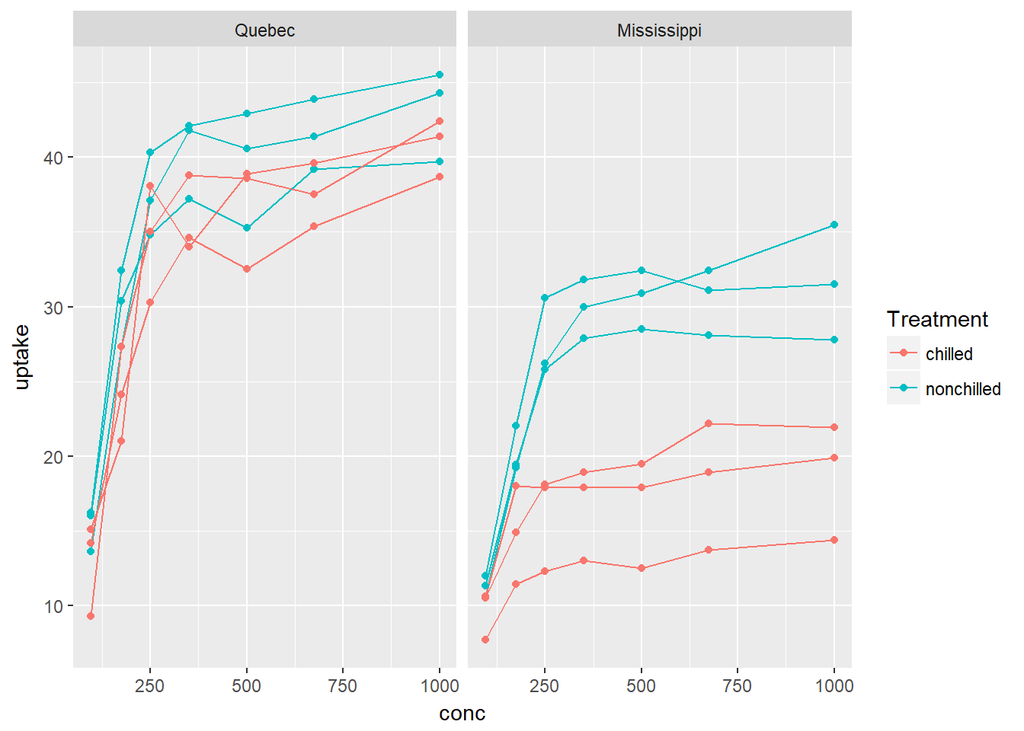

```r
library(ggplot2)

ggplot(CO2, aes(x = conc, y = uptake, color = Treatment)) +
  geom_line(aes(group = Plant)) +
  geom_point() +
  facet_wrap(~ Type)
```